# **Project: Machine Learning: Personal Loan Campaign**

## Business Context

Project: Machine Learning: Personal Loan Campaign Context: AllLife Bank is a US bank that has a growing customer base. The majority of these customers are liability customers (depositors) with varying sizes of deposits. The number of customers who are also borrowers (asset customers) is quite small, and the bank is interested in expanding this base rapidly to bring in more loan business and in the process, earn more through the interest on loans. In particular, the management wants to explore ways of converting its liability customers to personal loan customers (while retaining them as depositors).

A campaign that the bank ran last year for liability customers showed a healthy conversion rate of over 9% success. This has encouraged the retail marketing department to devise campaigns with better target marketing to increase the success ratio.

You as a Data Scientist at AllLife Bank have to build a model that will help the marketing department to identify the potential customers who have a higher probability of purchasing the loan.

## Objectives

To predict whether a liability customer will buy personal loans, to understand which customer attributes are most significant in driving purchases, and to identify which segment of customers to target more.

## Dataset Features Description

• **ID**: Unique Customer Identifier  
• **Age**: Customer's age in completed years  
• **Experience**: Years of professional experience  
• **Income**: Annual income (in thousand dollars)  
• **ZIP Code**: Home Address ZIP code  
• **Family**: Family size of the customer  
• **CCAvg**: Average monthly credit card spending (in thousand dollars)  
• **Education**: Education Level (1: Undergrad; 2: Graduate; 3: Advanced/Professional)  
• **Mortgage**: Value of house mortgage, if any (in thousand dollars)  
• **Personal_Loan**: Whether customer accepted personal loan in last campaign  
• **Securities_Account**: Whether customer has securities account with the bank  
• **CD_Account**: Whether customer has certificate of deposit account  
• **Online**: Whether customer uses internet banking facilities  
• **CreditCard**: Whether customer uses credit card from other banks (excluding All Life Bank)

# Installing and Importing the necessary libraries

```python
import pandas as pd
import numpy as np

# to visualize data
import matplotlib.pyplot as plt
import seaborn as sns
import plotly as pl

import warnings
warnings.filterwarnings("ignore")

# to split data into training and test sets
from sklearn.model_selection import train_test_split

# to build decision tree model
from sklearn.tree import DecisionTreeClassifier
from sklearn import tree

# to tune different models
from sklearn.model_selection import GridSearchCV

# to compute classification metrics
from sklearn.metrics import (
    confusion_matrix,
    accuracy_score,
    recall_score,
    precision_score,
    f1_score,
)
```

```python
pip install plotly
```

### Installing Library for Zip Code Conversion

```python
pip install pgeocode
```

# Loading the data

```python
data = pd.read_csv("C:\\Users\\User\\Desktop\\Learning\\Greate Learning\\ML\\Project\\Loan_Modelling.csv")
```

# Data overview

Viewing the first and last 5 rows of the dataset

```python
data.head(5)
```

|  | ID | Age | Experience | Income | ZIPCode | Family | CCAvg | Education | Mortgage | Personal_Loan | Securities_Account | CD_Account | Online | CreditCard |
| --- | --- | --- | --- | --- | --- | --- | --- | --- | --- | --- | --- | --- | --- | --- |
| 0 | 1 | 25 | 1 | 49 | 91107 | 4 | 1.6 | 1 | 0 | 0 | 1 | 0 | 0 | 0 |
| 1 | 2 | 45 | 19 | 34 | 90089 | 3 | 1.5 | 1 | 0 | 0 | 1 | 0 | 0 | 0 |
| 2 | 3 | 39 | 15 | 11 | 94720 | 1 | 1.0 | 1 | 0 | 0 | 0 | 0 | 0 | 0 |
| 3 | 4 | 35 | 9 | 100 | 94112 | 1 | 2.7 | 2 | 0 | 0 | 0 | 0 | 0 | 0 |
| 4 | 5 | 35 | 8 | 45 | 91330 | 4 | 1.0 | 2 | 0 | 0 | 0 | 0 | 0 | 1 |

```python
data.tail(5)
```

|  | ID | Age | Experience | Income | ZIPCode | Family | CCAvg | Education | Mortgage | Personal_Loan | Securities_Account | CD_Account | Online | CreditCard |
| --- | --- | --- | --- | --- | --- | --- | --- | --- | --- | --- | --- | --- | --- | --- |
| 4995 | 4996 | 29 | 3 | 40 | 92697 | 1 | 1.9 | 3 | 0 | 0 | 0 | 0 | 1 | 0 |
| 4996 | 4997 | 30 | 4 | 15 | 92037 | 4 | 0.4 | 1 | 85 | 0 | 0 | 0 | 1 | 0 |
| 4997 | 4998 | 63 | 39 | 24 | 93023 | 2 | 0.3 | 3 | 0 | 0 | 0 | 0 | 0 | 0 |
| 4998 | 4999 | 65 | 40 | 49 | 90034 | 3 | 0.5 | 2 | 0 | 0 | 0 | 0 | 1 | 0 |
| 4999 | 5000 | 28 | 4 | 83 | 92612 | 3 | 0.8 | 1 | 0 | 0 | 0 | 0 | 1 | 1 |

## Checking the shape of the dataset.

```python
data.shape
```

```
(5000, 14)
```

The datasheet has 5000 and 14 coloums

## Checking the attribute types

```python
data.info()
```

```
<class 'pandas.core.frame.DataFrame'>
RangeIndex: 5000 entries, 0 to 4999
Data columns (total 14 columns):
 #   Column              Non-Null Count  Dtype
---  ------              --------------  -----
 0   ID                  5000 non-null   int64
 1   Age                 5000 non-null   int64
 2   Experience          5000 non-null   int64
 3   Income              5000 non-null   int64
 4   ZIPCode             5000 non-null   int64
 5   Family              5000 non-null   int64
 6   CCAvg               5000 non-null   float64
 7   Education           5000 non-null   int64
 8   Mortgage            5000 non-null   int64
 9   Personal_Loan       5000 non-null   int64
 10  Securities_Account  5000 non-null   int64
 11  CD_Account          5000 non-null   int64
 12  Online              5000 non-null   int64
 13  CreditCard          5000 non-null   int64
dtypes: float64(1), int64(13)
memory usage: 547.0 KB
```

## Checking the statistical summary

```python
data.describe(include="all")
```

|  | ID | Age | Experience | Income | ZIPCode | Family | CCAvg | Education | Mortgage | Personal_Loan | Securities_Account | CD_Account | Online | CreditCard |
| --- | --- | --- | --- | --- | --- | --- | --- | --- | --- | --- | --- | --- | --- | --- |
| count | 5000.000000 | 5000.000000 | 5000.000000 | 5000.000000 | 5000.000000 | 5000.000000 | 5000.000000 | 5000.000000 | 5000.000000 | 5000.000000 | 5000.000000 | 5000.00000 | 5000.000000 | 5000.000000 |
| mean | 2500.500000 | 45.338400 | 20.104600 | 73.774200 | 93169.257000 | 2.396400 | 1.937938 | 1.881000 | 56.498800 | 0.096000 | 0.104400 | 0.06040 | 0.596800 | 0.294000 |
| std | 1443.520003 | 11.463166 | 11.467954 | 46.033729 | 1759.455086 | 1.147663 | 1.747659 | 0.839869 | 101.713802 | 0.294621 | 0.305809 | 0.23825 | 0.490589 | 0.455637 |
| min | 1.000000 | 23.000000 | -3.000000 | 8.000000 | 90005.000000 | 1.000000 | 0.000000 | 1.000000 | 0.000000 | 0.000000 | 0.000000 | 0.00000 | 0.000000 | 0.000000 |
| 25% | 1250.750000 | 35.000000 | 10.000000 | 39.000000 | 91911.000000 | 1.000000 | 0.700000 | 1.000000 | 0.000000 | 0.000000 | 0.000000 | 0.00000 | 0.000000 | 0.000000 |
| 50% | 2500.500000 | 45.000000 | 20.000000 | 64.000000 | 93437.000000 | 2.000000 | 1.500000 | 2.000000 | 0.000000 | 0.000000 | 0.000000 | 0.00000 | 1.000000 | 0.000000 |
| 75% | 3750.250000 | 55.000000 | 30.000000 | 98.000000 | 94608.000000 | 3.000000 | 2.500000 | 3.000000 | 101.000000 | 0.000000 | 0.000000 | 0.00000 | 1.000000 | 1.000000 |
| max | 5000.000000 | 67.000000 | 43.000000 | 224.000000 | 96651.000000 | 4.000000 | 10.000000 | 3.000000 | 635.000000 | 1.000000 | 1.000000 | 1.00000 | 1.000000 | 1.000000 |

## Data Quality Assessment Summary

### Demographic Profile:

Family size varies 1-4 members, suitable for categorical treatment

### Data Quality Issues Identified:

ZIP codes need preprocessing as categorical location identifiers Financial Characteristics: Education levels categorized as Undergrad/Graduate/Professional

Binary indicators for loan acceptance, securities/CD accounts, online banking, and external credit card usage

# Missing Values Check

```python
data.isnull().sum()
```

```
ID                    0
Age                   0
Experience            0
Income                0
ZIPCode               0
Family                0
CCAvg                 0
Education             0
Mortgage              0
Personal_Loan         0
Securities_Account    0
CD_Account            0
Online                0
CreditCard            0
dtype: int64
```

# Exploratory Data Analysis

# Univariate Analysis

### The continuous variables Age, Experience, Income, CCAvg, and Mortgage will be analyzed by plotting histograms and box plots.

```python
# function to create labeled barplots


def labeled_barplot(data, feature, perc=False, n=None):
    """
    Barplot with percentage at the top

    data: dataframe
    feature: dataframe column
    perc: whether to display percentages instead of count (default is False)
    n: displays the top n category levels (default is None, i.e., display all levels)
    """

    total = len(data[feature])  # length of the column
    count = data[feature].nunique()
    if n is None:
        plt.figure(figsize=(count + 2, 6))
    else:
        plt.figure(figsize=(n + 2, 6))

    plt.xticks(rotation=90, fontsize=15)
    ax = sns.countplot(
        data=data,
        x=feature,
        palette="Paired",
        order=data[feature].value_counts().index[:n],
    )

    for p in ax.patches:
        if perc == True:
            label = "{:.1f}%".format(
                100 * p.get_height() / total
            )  # percentage of each class of the category
        else:
            label = p.get_height()  # count of each level of the category

        x = p.get_x() + p.get_width() / 2  # width of the plot
        y = p.get_height()  # height of the plot

        ax.annotate(
            label,
            (x, y),
            ha="center",
            va="center",
            size=12,
            xytext=(0, 5),
            textcoords="offset points",
        )  # annotate the percentage

    plt.show()  # show the plotloc="upper left", bbox_to_anchor=(1, 1))
    plt.show()
```

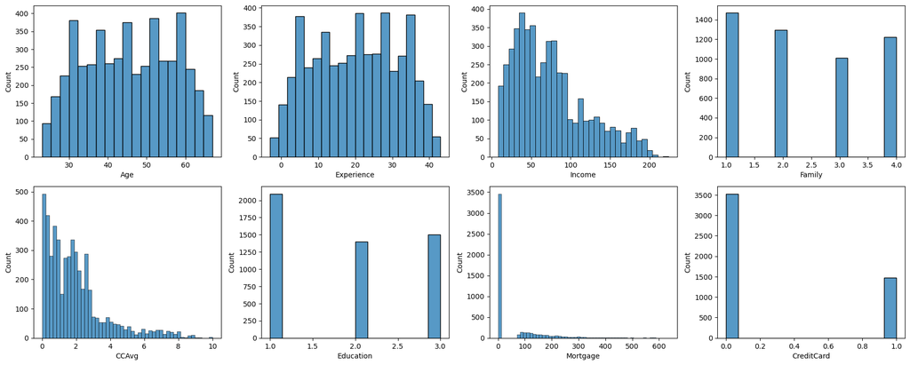

```python
# defining the figure size
plt.figure(figsize=(18, 14))

# defining the list of numerical features to plot
num_features = ['Age', 'Experience', 'Income','Family','CCAvg','Education','Mortgage','CreditCard']

# plotting the histogram for each numerical feature
for i,feature in enumerate(num_features):
    plt.subplot(4, 4, i+1)    # assign a subplot in the main plot
    sns.histplot(data=data, x=feature)    # plot the histogram

plt.tight_layout();   # to add spacing between plots
```

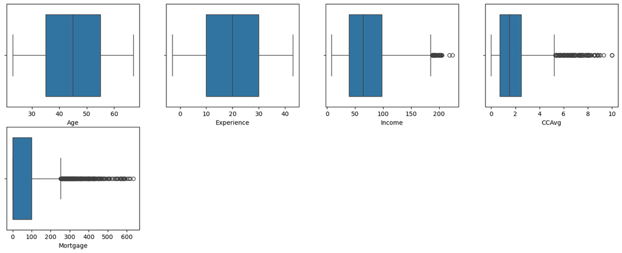

```python
# defining the figure size
plt.figure(figsize=(18, 14))

num_features = ['Age', 'Experience', 'Income','CCAvg','Mortgage']

# plotting the boxplot for each numerical feature
for i, feature in enumerate(num_features):
    plt.subplot(4, 4, i+1)    # assign a subplot in the main plot
    sns.boxplot(data=data, x=feature)   # plot the histogram
```

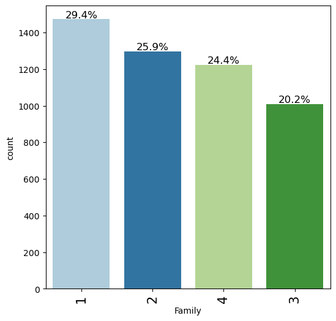

```python
labeled_barplot(data, "Family", perc=True)
```

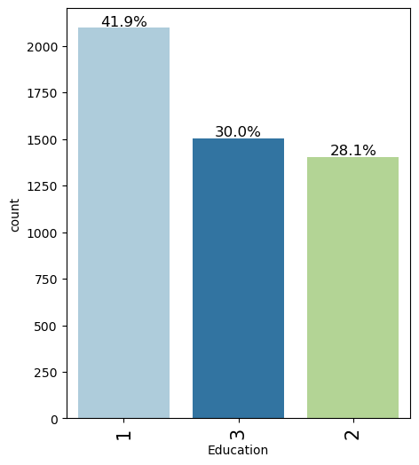

```python
labeled_barplot(data, "Education", perc=True)
```

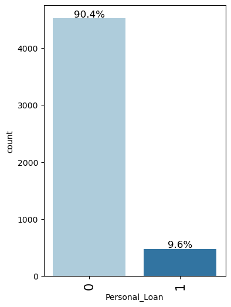

```python
labeled_barplot(data, "Personal_Loan", perc=True)
```

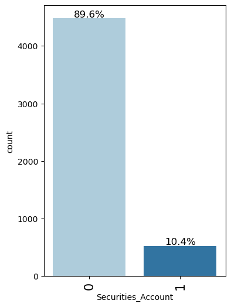

```python
labeled_barplot(data, "Securities_Account", perc=True)
```

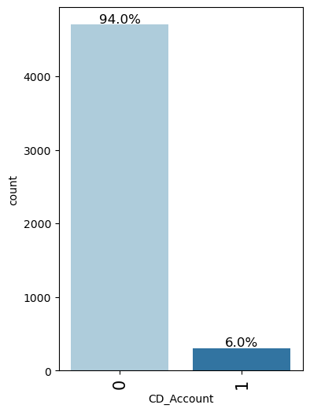

```python
labeled_barplot(data, "CD_Account", perc=True)
```

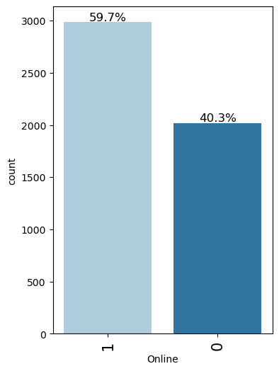

```python
labeled_barplot(data, "Online", perc=True)
```

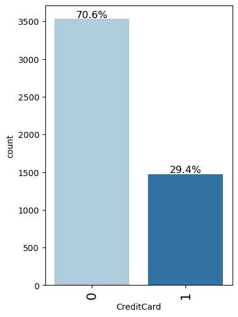

```python
labeled_barplot(data, "CreditCard", perc=True)
```

# 2. Bivariate analysis

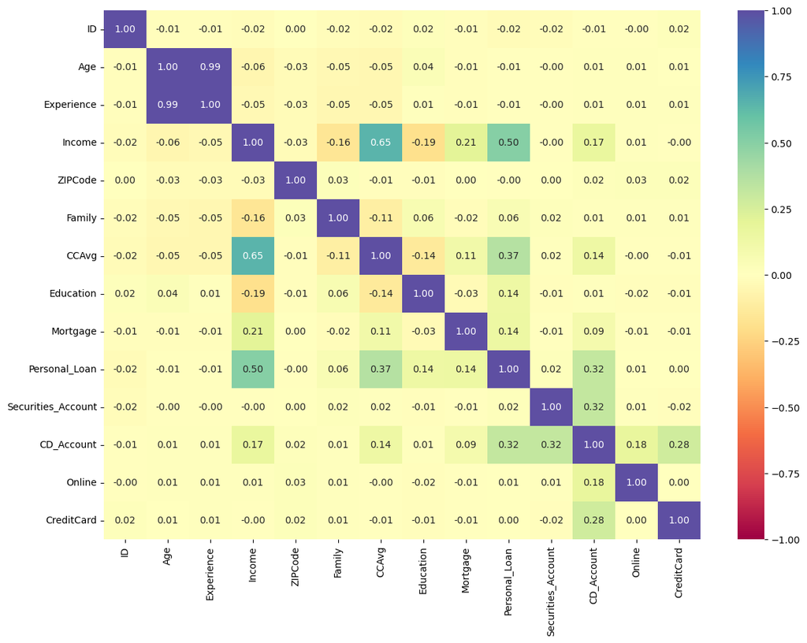

```python
# defining the size of the plot
plt.figure(figsize=(14, 10))

# plotting the heatmap for correlation
sns.heatmap(data.corr(),vmax=1,vmin=-1,annot=True,fmt=".2f", cmap="Spectral")
```

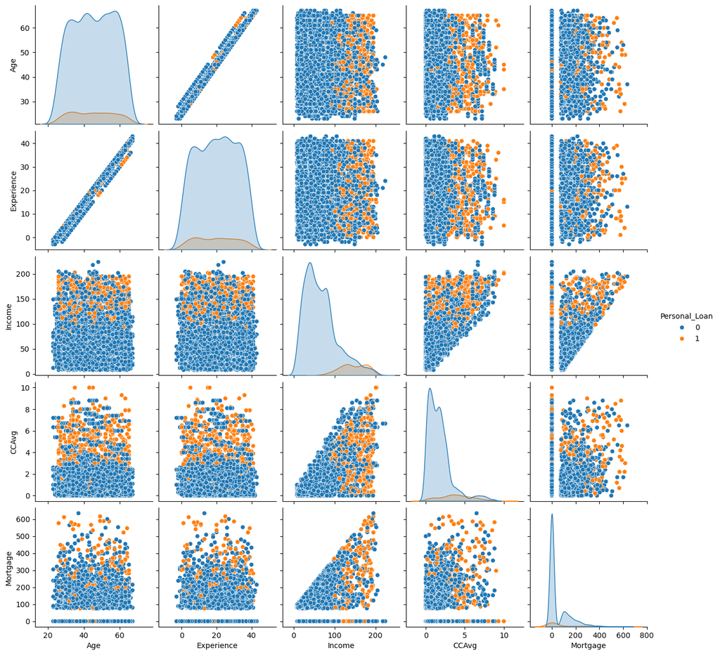

```python
# Scatter plot matrix
plt.figure(figsize=(12, 8))
sns.pairplot(data, vars=num_features, hue='Personal_Loan', diag_kind='kde');
```

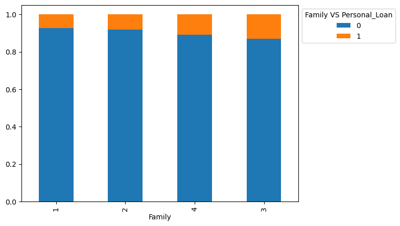

```python
# creating a crosstab for Family vs Personal_Loan
tab = pd.crosstab(
    data['Family'],
    data['Personal_Loan'],
    normalize='index'    # normalizing by dividing each row by its row total
).sort_values(by=0, ascending=False)    # sorting the resulting crosstab


# Plot the stacked bar chart
tab.plot(kind='bar', stacked=True, figsize=(7, 5))    # creating a stacked bar chart from the normalized crosstab
plt.xlabel('Family')
plt.legend(loc='upper left', bbox_to_anchor=(1, 1), title='Family VS Personal_Loan');    # adding a legend for the 'Approval' column
```

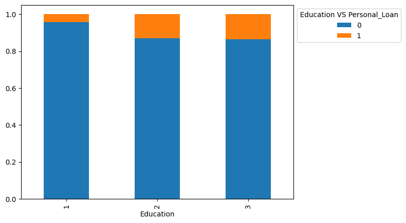

```python
# creating a crosstab for Education vs Personal_Loan
tab = pd.crosstab(
    data['Education'],
    data['Personal_Loan'],
    normalize='index'    # normalizing by dividing each row by its row total
).sort_values(by=0, ascending=False)    # sorting the resulting crosstab


# Plot the stacked bar chart
tab.plot(kind='bar', stacked=True, figsize=(7, 5))    # creating a stacked bar chart from the normalized crosstab
plt.xlabel('Education')
plt.legend(loc='upper left', bbox_to_anchor=(1, 1), title='Education VS Personal_Loan');    # adding a legend for the 'Approval' column
```

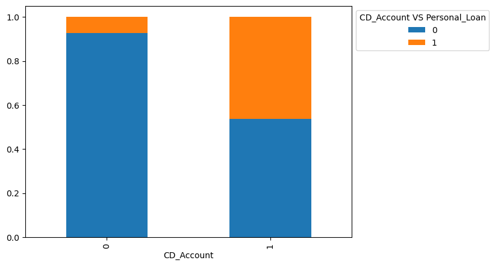

```python
# creating a crosstab for CD_Account vs Personal_Loan
tab = pd.crosstab(
    data['CD_Account'],
    data['Personal_Loan'],
    normalize='index'    # normalizing by dividing each row by its row total
).sort_values(by=0, ascending=False)    # sorting the resulting crosstab


# Plot the stacked bar chart
tab.plot(kind='bar', stacked=True, figsize=(7, 5))    # creating a stacked bar chart from the normalized crosstab
plt.xlabel('CD_Account')
plt.legend(loc='upper left', bbox_to_anchor=(1, 1), title='CD_Account VS Personal_Loan');    # adding a legend for the 'Approval' column
```

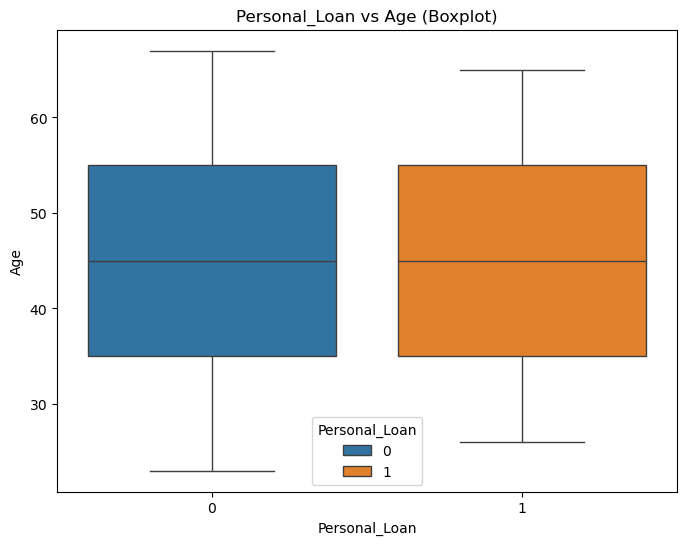

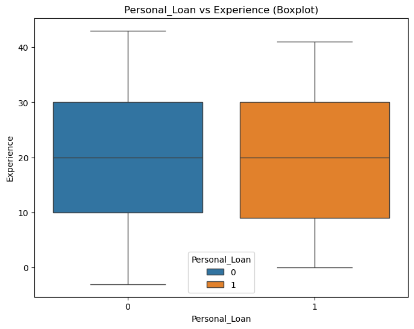

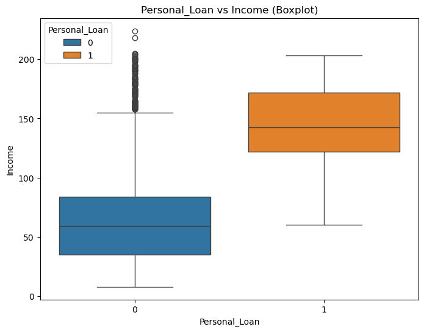

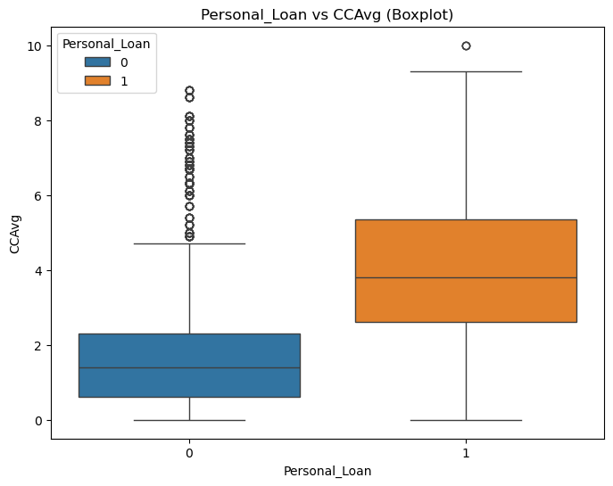

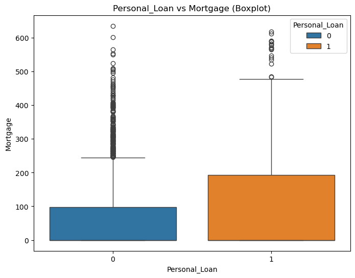

```python
# boxplots
plt.figure(figsize=(8, 6))
sns.boxplot(data=data, x='Personal_Loan', y='Age',hue='Personal_Loan')
plt.title('Personal_Loan vs Age (Boxplot)')
plt.show()

plt.figure(figsize=(8, 6))
sns.boxplot(data=data, x='Personal_Loan', y='Experience',hue='Personal_Loan')
plt.title('Personal_Loan vs Experience (Boxplot)')
plt.show()

plt.figure(figsize=(8, 6))
sns.boxplot(data=data, x='Personal_Loan', y='Income',hue='Personal_Loan')
plt.title('Personal_Loan vs Income (Boxplot)')
plt.show()

plt.figure(figsize=(8, 6))
sns.boxplot(data=data, x='Personal_Loan', y='CCAvg',hue='Personal_Loan')
plt.title('Personal_Loan vs CCAvg (Boxplot)')
plt.show()

plt.figure(figsize=(8, 6))
sns.boxplot(data=data, x='Personal_Loan', y='Mortgage',hue='Personal_Loan')
plt.title('Personal_Loan vs Mortgage (Boxplot)')
plt.show()
```

# Exploratory Data Analysis Summary

## 📊 Univariate Analysis Findings

### Categorical Variable Composition

#### Family Structure

- 29.4% Single individuals
- 25.9% Two-member families
- 24.4% Four-member families
- 20.2% Three-member families

#### Educational Background

- 41.9% Undergraduate degree holders
- 30.0% Advanced/Professional degrees
- 28.1% Graduate degree holders

### Financial Service Adoption

- **CD Accounts**: 94% without certificates of deposit, 6% with CD accounts
- **Online Banking**: 59.7% active users, 40.3% non-users
- **External Credit Cards**: 70.6% without external cards, 29.4% with external cards
- **Loan Acceptance**: 90.4% declined offers, 9.6% accepted personal loans

## 🔍 Multivariate Analysis Insights

### Target Variable Drivers

#### ⚠️ Neutral Factors (Minimal Impact)

- Online banking usage patterns
- Customer age demographics
- Professional experience duration
- External credit card ownership

### Feature Importance Assessment

#### Low Impact Predictors

- Age characteristics
- Professional experience
- Online banking usage
- External credit card usage

### Visual Analysis Confirmation

- **High-Income Clusters**: Loan acceptors concentrate above 100K(In Dollor) income threshold
- **Spending Patterns**: Acceptance density increases above 3K(In Dollor) monthly credit card spending
- **Family Dynamics**: Larger family units (3-4 members) show stronger adoption
- **Education Correlation**: Graduate/Professional degrees demonstrate higher conversion clusters

## 🎯 Key Business Insights

- Loan acceptance rate aligns with industry standards at 9.6%
- Clear demographic and financial patterns drive acceptance decisions
- Multiple right-skewed financial variables indicate wealth concentration
- Data provides actionable insights for targeted marketing strategies

# Data Preparation for Modeling

## Additing City and State information by using Zip Code Information

```python
import pgeocode

nomi = pgeocode.Nominatim('us')
def get_city_state(zipcode):
    result = nomi.query_postal_code(zipcode)
    if pd.isna(result['postal_code']):
        return pd.Series({'City': None, 'State': None})
    return pd.Series({
        'City': result['place_name'],
        'State': result['state_code']
    })


data[['City', 'State']] = data['ZIPCode'].apply(get_city_state)


print(data.head())
```

```
   ID  Age  Experience  Income  ZIPCode  Family  CCAvg  Education  Mortgage  \
0   1   25           1      49    91107       4    1.6          1         0
1   2   45          19      34    90089       3    1.5          1         0
2   3   39          15      11    94720       1    1.0          1         0
3   4   35           9     100    94112       1    2.7          2         0
4   5   35           8      45    91330       4    1.0          2         0

   Personal_Loan  Securities_Account  CD_Account  Online  CreditCard  \
0              0                   1           0       0           0
1              0                   1           0       0           0
2              0                   0           0       0           0
3              0                   0           0       0           0
4              0                   0           0       0           1

            City State
0       Pasadena    CA
1    Los Angeles    CA
2       Berkeley    CA
3  San Francisco    CA
4     Northridge    CA
```

```python
# defining the explanatory (independent) and response (dependent) variables
X = data.drop(["Personal_Loan",'State'], axis=1)
y = data["Personal_Loan"]

print(X.head())
print(y.head())
```

```
   ID  Age  Experience  Income  ZIPCode  Family  CCAvg  Education  Mortgage  \
0   1   25           1      49    91107       4    1.6          1         0
1   2   45          19      34    90089       3    1.5          1         0
2   3   39          15      11    94720       1    1.0          1         0
3   4   35           9     100    94112       1    2.7          2         0
4   5   35           8      45    91330       4    1.0          2         0

   Securities_Account  CD_Account  Online  CreditCard           City
0                   1           0       0           0       Pasadena
1                   1           0       0           0    Los Angeles
2                   0           0       0           0       Berkeley
3                   0           0       0           0  San Francisco
4                   0           0       0           1     Northridge
0    0
1    0
2    0
3    0
4    0
Name: Personal_Loan, dtype: int64
```

```python
X.info()
```

```
<class 'pandas.core.frame.DataFrame'>
RangeIndex: 5000 entries, 0 to 4999
Data columns (total 14 columns):
 #   Column              Non-Null Count  Dtype
---  ------              --------------  -----
 0   ID                  5000 non-null   int64
 1   Age                 5000 non-null   int64
 2   Experience          5000 non-null   int64
 3   Income              5000 non-null   int64
 4   ZIPCode             5000 non-null   int64
 5   Family              5000 non-null   int64
 6   CCAvg               5000 non-null   float64
 7   Education           5000 non-null   int64
 8   Mortgage            5000 non-null   int64
 9   Securities_Account  5000 non-null   int64
 10  CD_Account          5000 non-null   int64
 11  Online              5000 non-null   int64
 12  CreditCard          5000 non-null   int64
 13  City                4959 non-null   object
dtypes: float64(1), int64(12), object(1)
memory usage: 547.0+ KB
```

## Observed 41 missing City Information Adding Information Manually

```python
#extracting the zipcodes that are returning the nan values
zip_nan = X[X['City'].isnull()]
zip_nan['ZIPCode'].value_counts()
```

```
ZIPCode
92717    22
92709     7
96651     6
92634     5
93077     1
Name: count, dtype: int64
```

```python
# Create a dictionary with the Zip code googled City
zip_dict = {'92717': 'Irvine',
            '92709': 'Santa Ana',
            '92634': 'Fountain Valley',
            '93077': 'Simi Valley',
            '96651': 'Lotus'
           }

# Create a function to fill the missing values
def fill_nan(data, indxs, value, column):
    for i in indxs:
        data[column].iloc[i] = value

# Create a for loop to fill in the missing city values
for i in zip_dict.keys():
    # Convert ZIP code to string for comparison (assuming ZIPCode column might be string or numeric)
    indxs = X[X['ZIPCode'].astype(str) == i].index
    fill_nan(X, indxs, zip_dict[i], 'City')



# Confirm null values are removed in City column and State column is dropped
print("Null values after processing:")
print(X.isnull().sum())
print("\nColumn names after dropping State:")
print(X.columns.tolist())
```

```
Null values after processing:
ID                    0
Age                   0
Experience            0
Income                0
ZIPCode               0
Family                0
CCAvg                 0
Education             0
Mortgage              0
Securities_Account    0
CD_Account            0
Online                0
CreditCard            0
City                  0
dtype: int64

Column names after dropping State:
['ID', 'Age', 'Experience', 'Income', 'ZIPCode', 'Family', 'CCAvg', 'Education', 'Mortgage', 'Securities_Account', 'CD_Account', 'Online', 'CreditCard', 'City']
```

```python
X.info()
```

```
<class 'pandas.core.frame.DataFrame'>
RangeIndex: 5000 entries, 0 to 4999
Data columns (total 14 columns):
 #   Column              Non-Null Count  Dtype
---  ------              --------------  -----
 0   ID                  5000 non-null   int64
 1   Age                 5000 non-null   int64
 2   Experience          5000 non-null   int64
 3   Income              5000 non-null   int64
 4   ZIPCode             5000 non-null   int64
 5   Family              5000 non-null   int64
 6   CCAvg               5000 non-null   float64
 7   Education           5000 non-null   int64
 8   Mortgage            5000 non-null   int64
 9   Securities_Account  5000 non-null   int64
 10  CD_Account          5000 non-null   int64
 11  Online              5000 non-null   int64
 12  CreditCard          5000 non-null   int64
 13  City                5000 non-null   object
dtypes: float64(1), int64(12), object(1)
memory usage: 547.0+ KB
```

## Now No null values are remaining

### Having a look before Converting the city information to integer before using lable encoder

```python
print(X.head())
```

```
   ID  Age  Experience  Income  ZIPCode  Family  CCAvg  Education  Mortgage  \
0   1   25           1      49    91107       4    1.6          1         0
1   2   45          19      34    90089       3    1.5          1         0
2   3   39          15      11    94720       1    1.0          1         0
3   4   35           9     100    94112       1    2.7          2         0
4   5   35           8      45    91330       4    1.0          2         0

   Securities_Account  CD_Account  Online  CreditCard           City
0                   1           0       0           0       Pasadena
1                   1           0       0           0    Los Angeles
2                   0           0       0           0       Berkeley
3                   0           0       0           0  San Francisco
4                   0           0       0           1     Northridge
```

```python
from sklearn.preprocessing import LabelEncoder

# Convert the 'City' column to string type first, then fill missing values
X['City'] = X['City'].astype(str).fillna('Unknown')

# Initialize and apply label encoder
city_encoder = LabelEncoder()
X['City'] = city_encoder.fit_transform(X['City'])

# The DataFrame X now has the encoded 'City' column and other columns
# We don't need to convert the whole DataFrame to float here

print("Shape after encoding:", X.shape)
print("\nFirst few rows:")
print(X.head())
print("\nColumn names:")
print(X.columns.tolist())
print(f"\nTotal cities encoded: {len(city_encoder.classes_)}")
```

```
Shape after encoding: (5000, 14)

First few rows:
   ID  Age  Experience  Income  ZIPCode  Family  CCAvg  Education  Mortgage  \
0   1   25           1      49    91107       4    1.6          1         0
1   2   45          19      34    90089       3    1.5          1         0
2   3   39          15      11    94720       1    1.0          1         0
3   4   35           9     100    94112       1    2.7          2         0
4   5   35           8      45    91330       4    1.0          2         0

   Securities_Account  CD_Account  Online  CreditCard  City
0                   1           0       0           0   149
1                   1           0       0           0   107
2                   0           0       0           0    17
3                   0           0       0           0   180
4                   0           0       0           1   136

Column names:
['ID', 'Age', 'Experience', 'Income', 'ZIPCode', 'Family', 'CCAvg', 'Education', 'Mortgage', 'Securities_Account', 'CD_Account', 'Online', 'CreditCard', 'City']

Total cities encoded: 246
```

### Converted String Values to Interger values of "City"

### Checking the Data Information again

```python
print(X.isnull().sum())
```

```
ID                    0
Age                   0
Experience            0
Income                0
ZIPCode               0
Family                0
CCAvg                 0
Education             0
Mortgage              0
Securities_Account    0
CD_Account            0
Online                0
CreditCard            0
City                  0
dtype: int64
```

```python
X.info()
```

```
<class 'pandas.core.frame.DataFrame'>
RangeIndex: 5000 entries, 0 to 4999
Data columns (total 14 columns):
 #   Column              Non-Null Count  Dtype
---  ------              --------------  -----
 0   ID                  5000 non-null   int64
 1   Age                 5000 non-null   int64
 2   Experience          5000 non-null   int64
 3   Income              5000 non-null   int64
 4   ZIPCode             5000 non-null   int64
 5   Family              5000 non-null   int64
 6   CCAvg               5000 non-null   float64
 7   Education           5000 non-null   int64
 8   Mortgage            5000 non-null   int64
 9   Securities_Account  5000 non-null   int64
 10  CD_Account          5000 non-null   int64
 11  Online              5000 non-null   int64
 12  CreditCard          5000 non-null   int64
 13  City                5000 non-null   int64
dtypes: float64(1), int64(13)
memory usage: 547.0 KB
```

```python
y.info()
```

```
<class 'pandas.core.series.Series'>
RangeIndex: 5000 entries, 0 to 4999
Series name: Personal_Loan
Non-Null Count  Dtype
--------------  -----
5000 non-null   int64
dtypes: int64(1)
memory usage: 39.2 KB
```

```python
X = X.drop(["ZIPCode"], axis=1)
X.info()
```

```
<class 'pandas.core.frame.DataFrame'>
RangeIndex: 5000 entries, 0 to 4999
Data columns (total 13 columns):
 #   Column              Non-Null Count  Dtype
---  ------              --------------  -----
 0   ID                  5000 non-null   int64
 1   Age                 5000 non-null   int64
 2   Experience          5000 non-null   int64
 3   Income              5000 non-null   int64
 4   Family              5000 non-null   int64
 5   CCAvg               5000 non-null   float64
 6   Education           5000 non-null   int64
 7   Mortgage            5000 non-null   int64
 8   Securities_Account  5000 non-null   int64
 9   CD_Account          5000 non-null   int64
 10  Online              5000 non-null   int64
 11  CreditCard          5000 non-null   int64
 12  City                5000 non-null   int64
dtypes: float64(1), int64(12)
memory usage: 507.9 KB
```

```python
X.head()
```

|  | ID | Age | Experience | Income | Family | CCAvg | Education | Mortgage | Securities_Account | CD_Account | Online | CreditCard | City |
| --- | --- | --- | --- | --- | --- | --- | --- | --- | --- | --- | --- | --- | --- |
| 0 | 1 | 25 | 1 | 49 | 4 | 1.6 | 1 | 0 | 1 | 0 | 0 | 0 | 149 |
| 1 | 2 | 45 | 19 | 34 | 3 | 1.5 | 1 | 0 | 1 | 0 | 0 | 0 | 107 |
| 2 | 3 | 39 | 15 | 11 | 1 | 1.0 | 1 | 0 | 0 | 0 | 0 | 0 | 17 |
| 3 | 4 | 35 | 9 | 100 | 1 | 2.7 | 2 | 0 | 0 | 0 | 0 | 0 | 180 |
| 4 | 5 | 35 | 8 | 45 | 4 | 1.0 | 2 | 0 | 0 | 0 | 0 | 1 | 136 |

## Checking for Negative Integer in Experience Section

```python
(X['Experience'] < 0).sum()
```

```
np.int64(52)
```

### Total 52 records show Negative Experiece

```python
X[X['Experience'] < 0]
```

|  | ID | Age | Experience | Income | Family | CCAvg | Education | Mortgage | Securities_Account | CD_Account | Online | CreditCard | City |
| --- | --- | --- | --- | --- | --- | --- | --- | --- | --- | --- | --- | --- | --- |
| 89 | 90 | 25 | -1 | 113 | 4 | 2.30 | 3 | 0 | 0 | 0 | 0 | 1 | 147 |
| 226 | 227 | 24 | -1 | 39 | 2 | 1.70 | 2 | 0 | 0 | 0 | 0 | 0 | 221 |
| 315 | 316 | 24 | -2 | 51 | 3 | 0.30 | 3 | 0 | 0 | 0 | 1 | 0 | 51 |
| 451 | 452 | 28 | -2 | 48 | 2 | 1.75 | 3 | 89 | 0 | 0 | 1 | 0 | 180 |
| 524 | 525 | 24 | -1 | 75 | 4 | 0.20 | 1 | 0 | 0 | 0 | 1 | 0 | 33 |
| 536 | 537 | 25 | -1 | 43 | 3 | 2.40 | 2 | 176 | 0 | 0 | 1 | 0 | 193 |
| 540 | 541 | 25 | -1 | 109 | 4 | 2.30 | 3 | 314 | 0 | 0 | 1 | 0 | 24 |
| 576 | 577 | 25 | -1 | 48 | 3 | 0.30 | 3 | 0 | 0 | 0 | 0 | 1 | 150 |
| 583 | 584 | 24 | -1 | 38 | 2 | 1.70 | 2 | 0 | 0 | 0 | 1 | 0 | 183 |
| 597 | 598 | 24 | -2 | 125 | 2 | 7.20 | 1 | 0 | 1 | 0 | 0 | 1 | 72 |
| 649 | 650 | 25 | -1 | 82 | 4 | 2.10 | 3 | 0 | 0 | 0 | 1 | 0 | 97 |
| 670 | 671 | 23 | -1 | 61 | 4 | 2.60 | 1 | 239 | 0 | 0 | 1 | 0 | 161 |
| 686 | 687 | 24 | -1 | 38 | 4 | 0.60 | 2 | 0 | 0 | 0 | 1 | 0 | 90 |
| 793 | 794 | 24 | -2 | 150 | 2 | 2.00 | 1 | 0 | 0 | 0 | 1 | 0 | 17 |
| 889 | 890 | 24 | -2 | 82 | 2 | 1.60 | 3 | 0 | 0 | 0 | 1 | 1 | 149 |
| 909 | 910 | 23 | -1 | 149 | 1 | 6.33 | 1 | 305 | 0 | 0 | 0 | 1 | 40 |
| 1173 | 1174 | 24 | -1 | 35 | 2 | 1.70 | 2 | 0 | 0 | 0 | 0 | 0 | 216 |
| 1428 | 1429 | 25 | -1 | 21 | 4 | 0.40 | 1 | 90 | 0 | 0 | 1 | 0 | 192 |
| 1522 | 1523 | 25 | -1 | 101 | 4 | 2.30 | 3 | 256 | 0 | 0 | 0 | 1 | 17 |
| 1905 | 1906 | 25 | -1 | 112 | 2 | 2.00 | 1 | 241 | 0 | 0 | 1 | 0 | 168 |
| 2102 | 2103 | 25 | -1 | 81 | 2 | 1.60 | 3 | 0 | 0 | 0 | 1 | 1 | 87 |
| 2430 | 2431 | 23 | -1 | 73 | 4 | 2.60 | 1 | 0 | 0 | 0 | 1 | 0 | 178 |
| 2466 | 2467 | 24 | -2 | 80 | 2 | 1.60 | 3 | 0 | 0 | 0 | 1 | 0 | 180 |
| 2545 | 2546 | 25 | -1 | 39 | 3 | 2.40 | 2 | 0 | 0 | 0 | 1 | 0 | 17 |
| 2618 | 2619 | 23 | -3 | 55 | 3 | 2.40 | 2 | 145 | 0 | 0 | 1 | 0 | 195 |
| 2717 | 2718 | 23 | -2 | 45 | 4 | 0.60 | 2 | 0 | 0 | 0 | 1 | 1 | 44 |
| 2848 | 2849 | 24 | -1 | 78 | 2 | 1.80 | 2 | 0 | 0 | 0 | 0 | 0 | 17 |
| 2876 | 2877 | 24 | -2 | 80 | 2 | 1.60 | 3 | 238 | 0 | 0 | 0 | 0 | 149 |
| 2962 | 2963 | 23 | -2 | 81 | 2 | 1.80 | 2 | 0 | 0 | 0 | 0 | 0 | 43 |
| 2980 | 2981 | 25 | -1 | 53 | 3 | 2.40 | 2 | 0 | 0 | 0 | 0 | 0 | 216 |
| 3076 | 3077 | 29 | -1 | 62 | 2 | 1.75 | 3 | 0 | 0 | 0 | 0 | 1 | 177 |
| 3130 | 3131 | 23 | -2 | 82 | 2 | 1.80 | 2 | 0 | 1 | 0 | 0 | 1 | 178 |
| 3157 | 3158 | 23 | -1 | 13 | 4 | 1.00 | 1 | 84 | 0 | 0 | 1 | 0 | 17 |
| 3279 | 3280 | 26 | -1 | 44 | 1 | 2.00 | 2 | 0 | 0 | 0 | 0 | 0 | 191 |
| 3284 | 3285 | 25 | -1 | 101 | 4 | 2.10 | 3 | 0 | 0 | 0 | 0 | 1 | 172 |
| 3292 | 3293 | 25 | -1 | 13 | 4 | 0.40 | 1 | 0 | 1 | 0 | 0 | 0 | 54 |
| 3394 | 3395 | 25 | -1 | 113 | 4 | 2.10 | 3 | 0 | 0 | 0 | 1 | 0 | 107 |
| 3425 | 3426 | 23 | -1 | 12 | 4 | 1.00 | 1 | 90 | 0 | 0 | 1 | 0 | 135 |
| 3626 | 3627 | 24 | -3 | 28 | 4 | 1.00 | 3 | 0 | 0 | 0 | 0 | 0 | 107 |
| 3796 | 3797 | 24 | -2 | 50 | 3 | 2.40 | 2 | 0 | 1 | 0 | 0 | 0 | 15 |
| 3824 | 3825 | 23 | -1 | 12 | 4 | 1.00 | 1 | 0 | 1 | 0 | 0 | 1 | 199 |
| 3887 | 3888 | 24 | -2 | 118 | 2 | 7.20 | 1 | 0 | 1 | 0 | 1 | 0 | 69 |
| 3946 | 3947 | 25 | -1 | 40 | 3 | 2.40 | 2 | 0 | 0 | 0 | 1 | 0 | 77 |
| 4015 | 4016 | 25 | -1 | 139 | 2 | 2.00 | 1 | 0 | 0 | 0 | 0 | 1 | 196 |
| 4088 | 4089 | 29 | -1 | 71 | 2 | 1.75 | 3 | 0 | 0 | 0 | 0 | 0 | 165 |
| 4116 | 4117 | 24 | -2 | 135 | 2 | 7.20 | 1 | 0 | 0 | 0 | 1 | 0 | 107 |
| 4285 | 4286 | 23 | -3 | 149 | 2 | 7.20 | 1 | 0 | 0 | 0 | 1 | 0 | 166 |
| 4411 | 4412 | 23 | -2 | 75 | 2 | 1.80 | 2 | 0 | 0 | 0 | 1 | 1 | 234 |
| 4481 | 4482 | 25 | -2 | 35 | 4 | 1.00 | 3 | 0 | 0 | 0 | 1 | 0 | 183 |
| 4514 | 4515 | 24 | -3 | 41 | 4 | 1.00 | 3 | 0 | 0 | 0 | 1 | 0 | 153 |
| 4582 | 4583 | 25 | -1 | 69 | 3 | 0.30 | 3 | 0 | 0 | 0 | 1 | 0 | 118 |
| 4957 | 4958 | 29 | -1 | 50 | 2 | 1.75 | 3 | 0 | 0 | 0 | 0 | 1 | 172 |

```python
X.loc[X['Experience'] < 0, 'Experience'] = X.loc[X['Experience'] < 0, 'Experience'].abs()
```

```python
(X['Experience'] < 0).sum()
```

```
np.int64(0)
```

### All the negative experience values are converted to positive values considering the typo or manual mistaken

```python
X_train, X_test, y_train, y_test = train_test_split(X, y, test_size=0.20, random_state=42)
```

```python
#Checking the train and test dataset sizes for confirmation
print(f'X_train shape:{X_train.shape}')
print(f'X_test shape:{X_test.shape}')
```

```
X_train shape:(4000, 13)
X_test shape:(1000, 13)
```

```python
print("Percentage of classes in training set:")
print(y_train.value_counts(normalize=True))
print("Percentage of classes in test set:")
print(y_test.value_counts(normalize=True))
```

```
Percentage of classes in training set:
Personal_Loan
0    0.90625
1    0.09375
Name: proportion, dtype: float64
Percentage of classes in test set:
Personal_Loan
0    0.895
1    0.105
Name: proportion, dtype: float64
```

# Model Building

## Decision Tree (sklearn default)

```python
# creating an instance of the decision tree model
dtree1 = DecisionTreeClassifier(random_state=42)    # random_state sets a seed value and enables reproducibility

# fitting the model to the training data
dtree1.fit(X_train, y_train)
```

```
DecisionTreeClassifier(random_state=42)
```

# Model Evaluation

#### We define a utility function to collate all the metrics into a single data frame, and another to plot the confusion matrix.

```python
# defining a function to compute different metrics to check performance of a classification model built using sklearn
def model_performance_classification(model, predictors, target):
    """
    Function to compute different metrics to check classification model performance

    model: classifier
    predictors: independent variables
    target: dependent variable
    """

    # predicting using the independent variables
    pred = model.predict(predictors)

    acc = accuracy_score(target, pred)  # to compute Accuracy
    recall = recall_score(target, pred)  # to compute Recall
    precision = precision_score(target, pred)  # to compute Precision
    f1 = f1_score(target, pred)  # to compute F1-score

    # creating a dataframe of metrics
    df_perf = pd.DataFrame(
        {"Accuracy": acc, "Recall": recall, "Precision": precision, "F1": f1,},
        index=[0],
    )

    return df_perf
```

```python
def plot_confusion_matrix(model, predictors, target):
    """
    To plot the confusion_matrix with percentages

    model: classifier
    predictors: independent variables
    target: dependent variable
    """
    # Predict the target values using the provided model and predictors
    y_pred = model.predict(predictors)

    # Compute the confusion matrix comparing the true target values with the predicted values
    cm = confusion_matrix(target, y_pred)

    # Create labels for each cell in the confusion matrix with both count and percentage
    labels = np.asarray(
        [
            ["{0:0.0f}".format(item) + "\n{0:.2%}".format(item / cm.flatten().sum())]
            for item in cm.flatten()
        ]
    ).reshape(2, 2)    # reshaping to a matrix

    # Set the figure size for the plot
    plt.figure(figsize=(6, 4))

    # Plot the confusion matrix as a heatmap with the labels
    sns.heatmap(cm, annot=labels, fmt="")

    # Add a label to the y-axis
    plt.ylabel("True label")

    # Add a label to the x-axis
    plt.xlabel("Predicted label")
```

##### Note: We want to maximize the F1 Score to ensure that we reduce both the chances of approving non-credible applications as well as rejecting credible ones.

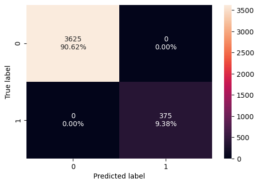

```python
plot_confusion_matrix(dtree1, X_train, y_train)
```

```python
dtree1_train_perf = model_performance_classification(
    dtree1, X_train, y_train
)
dtree1_train_perf
```

|  | Accuracy | Recall | Precision | F1 |
| --- | --- | --- | --- | --- |
| 0 | 1.0 | 1.0 | 1.0 | 1.0 |

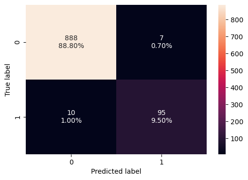

```python
plot_confusion_matrix(dtree1, X_test, y_test)
```

```python
X_test.head()
```

|  | ID | Age | Experience | Income | Family | CCAvg | Education | Mortgage | Securities_Account | CD_Account | Online | CreditCard | City |
| --- | --- | --- | --- | --- | --- | --- | --- | --- | --- | --- | --- | --- | --- |
| 1501 | 1502 | 30 | 4 | 35 | 2 | 0.3 | 2 | 0 | 1 | 0 | 0 | 1 | 178 |
| 2586 | 2587 | 47 | 23 | 149 | 4 | 6.1 | 1 | 0 | 0 | 0 | 0 | 1 | 184 |
| 2653 | 2654 | 30 | 5 | 121 | 2 | 3.1 | 1 | 408 | 0 | 0 | 1 | 0 | 70 |
| 1055 | 1056 | 31 | 6 | 62 | 1 | 1.0 | 1 | 0 | 1 | 0 | 1 | 0 | 68 |
| 705 | 706 | 62 | 36 | 30 | 3 | 0.7 | 2 | 0 | 0 | 0 | 1 | 0 | 17 |

```python
dtree1_test_perf = model_performance_classification(
    dtree1, X_test, y_test
)
dtree1_test_perf
```

|  | Accuracy | Recall | Precision | F1 |
| --- | --- | --- | --- | --- |
| 0 | 0.983 | 0.904762 | 0.931373 | 0.917874 |

1. There is a huge difference between the training and test F1 Scores.
2. This indicates that the model is overfitting.

# Visualizing the Decision Tree

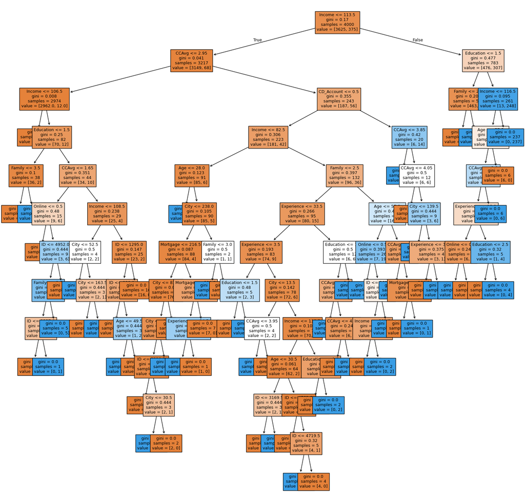

```python
# list of feature names in X_train
feature_names = list(X_train.columns)

# set the figure size for the plot
plt.figure(figsize=(20, 20))

# plotting the decision tree
out = tree.plot_tree(
    dtree1,                         # decision tree classifier model
    feature_names=feature_names,    # list of feature names (columns) in the dataset
    filled=True,                    # fill the nodes with colors based on class
    fontsize=9,                     # font size for the node text
    node_ids=False,                 # do not show the ID of each node
    class_names=None,               # whether or not to display class names
)

# add arrows to the decision tree splits if they are missing
for o in out:
    arrow = o.arrow_patch
    if arrow is not None:
        arrow.set_edgecolor("black")    # set arrow color to black
        arrow.set_linewidth(1)          # set arrow linewidth to 1

# displaying the plot
plt.show()
```

We can observe that this is a very complex tree.

```python
# printing a text report showing the rules of a decision tree
print(
    tree.export_text(
        dtree1,    # specify the model
        feature_names=feature_names,    # specify the feature names
        show_weights=True    # specify whether or not to show the weights associated with the model
    )
)
```

```
|--- Income <= 113.50
|   |--- CCAvg <= 2.95
|   |   |--- Income <= 106.50
|   |   |   |--- weights: [2892.00, 0.00] class: 0
|   |   |--- Income >  106.50
|   |   |   |--- Education <= 1.50
|   |   |   |   |--- Family <= 3.50
|   |   |   |   |   |--- weights: [36.00, 0.00] class: 0
|   |   |   |   |--- Family >  3.50
|   |   |   |   |   |--- weights: [0.00, 2.00] class: 1
|   |   |   |--- Education >  1.50
|   |   |   |   |--- CCAvg <= 1.65
|   |   |   |   |   |--- Online <= 0.50
|   |   |   |   |   |   |--- weights: [6.00, 0.00] class: 0
|   |   |   |   |   |--- Online >  0.50
|   |   |   |   |   |   |--- ID <= 4952.00
|   |   |   |   |   |   |   |--- Family <= 1.50
|   |   |   |   |   |   |   |   |--- ID <= 2337.00
|   |   |   |   |   |   |   |   |   |--- weights: [2.00, 0.00] class: 0
|   |   |   |   |   |   |   |   |--- ID >  2337.00
|   |   |   |   |   |   |   |   |   |--- weights: [0.00, 1.00] class: 1
|   |   |   |   |   |   |   |--- Family >  1.50
|   |   |   |   |   |   |   |   |--- weights: [0.00, 5.00] class: 1
|   |   |   |   |   |   |--- ID >  4952.00
|   |   |   |   |   |   |   |--- weights: [1.00, 0.00] class: 0
|   |   |   |   |--- CCAvg >  1.65
|   |   |   |   |   |--- Income <= 108.50
|   |   |   |   |   |   |--- City <= 52.50
|   |   |   |   |   |   |   |--- weights: [0.00, 1.00] class: 1
|   |   |   |   |   |   |--- City >  52.50
|   |   |   |   |   |   |   |--- City <= 163.50
|   |   |   |   |   |   |   |   |--- weights: [2.00, 0.00] class: 0
|   |   |   |   |   |   |   |--- City >  163.50
|   |   |   |   |   |   |   |   |--- weights: [0.00, 1.00] class: 1
|   |   |   |   |   |--- Income >  108.50
|   |   |   |   |   |   |--- ID <= 1295.00
|   |   |   |   |   |   |   |--- ID <= 990.00
|   |   |   |   |   |   |   |   |--- weights: [6.00, 0.00] class: 0
|   |   |   |   |   |   |   |--- ID >  990.00
|   |   |   |   |   |   |   |   |--- Age <= 49.50
```

[output cut: 126 more lines]

```
|   |   |   |   |   |   |--- Online <= 0.50
|   |   |   |   |   |   |   |--- weights: [0.00, 1.00] class: 1
|   |   |   |   |   |   |--- Online >  0.50
|   |   |   |   |   |   |   |--- weights: [6.00, 0.00] class: 0
|   |   |   |   |   |--- Experience >  18.00
|   |   |   |   |   |   |--- Education <= 2.50
|   |   |   |   |   |   |   |--- weights: [1.00, 0.00] class: 0
|   |   |   |   |   |   |--- Education >  2.50
|   |   |   |   |   |   |   |--- weights: [0.00, 4.00] class: 1
|   |   |   |   |--- CCAvg >  2.80
|   |   |   |   |   |--- weights: [0.00, 6.00] class: 1
|   |   |   |--- Age >  57.50
|   |   |   |   |--- weights: [6.00, 0.00] class: 0
|   |   |--- Income >  116.50
|   |   |   |--- weights: [0.00, 237.00] class: 1
```

# Decision Tree (Pre-pruning)

```python
# define the parameters of the tree to iterate over
max_depth_values = np.arange(2, 11, 2)
max_leaf_nodes_values = np.arange(10, 51, 10)
min_samples_split_values = np.arange(10, 51, 10)

# initialize variables to store the best model and its performance
best_estimator = None
best_score_diff = float('inf')

# iterate over all combinations of the specified parameter values
for max_depth in max_depth_values:
    for max_leaf_nodes in max_leaf_nodes_values:
        for min_samples_split in min_samples_split_values:

            # initialize the tree with the current set of parameters
            estimator = DecisionTreeClassifier(
                max_depth=max_depth,
                max_leaf_nodes=max_leaf_nodes,
                min_samples_split=min_samples_split,
                random_state=42
            )

            # fit the model to the training data
            estimator.fit(X_train, y_train)

            # make predictions on the training and test sets
            y_train_pred = estimator.predict(X_train)
            y_test_pred = estimator.predict(X_test)

            # calculate F1 scores for training and test sets
            train_f1_score = f1_score(y_train, y_train_pred)
            test_f1_score = f1_score(y_test, y_test_pred)

            # calculate the absolute difference between training and test F1 scores
            score_diff = abs(train_f1_score - test_f1_score)

            # update the best estimator and best score if the current one has a smaller score difference
            if score_diff < best_score_diff:
                best_score_diff = score_diff
                best_estimator = estimator
```

```python
# creating an instance of the best model
dtree2 = best_estimator

# fitting the best model to the training data
dtree2.fit(X_train, y_train)
```

```
DecisionTreeClassifier(max_depth=np.int64(8), max_leaf_nodes=np.int64(20),
                       min_samples_split=np.int64(30), random_state=42)
```

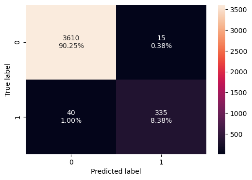

```python
plot_confusion_matrix(dtree2, X_train, y_train)
```

```python
dtree2_train_perf = model_performance_classification(
    dtree2, X_train, y_train
)
dtree2_train_perf
```

|  | Accuracy | Recall | Precision | F1 |
| --- | --- | --- | --- | --- |
| 0 | 0.98625 | 0.893333 | 0.957143 | 0.924138 |

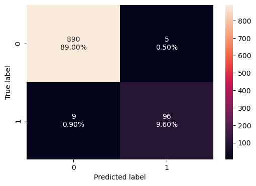

```python
plot_confusion_matrix(dtree2, X_test, y_test)
```

```python
dtree2_test_perf = model_performance_classification(
    dtree2, X_test, y_test
)
dtree2_test_perf
```

|  | Accuracy | Recall | Precision | F1 |
| --- | --- | --- | --- | --- |
| 0 | 0.986 | 0.914286 | 0.950495 | 0.932039 |

# Visualizing the Decision Tree

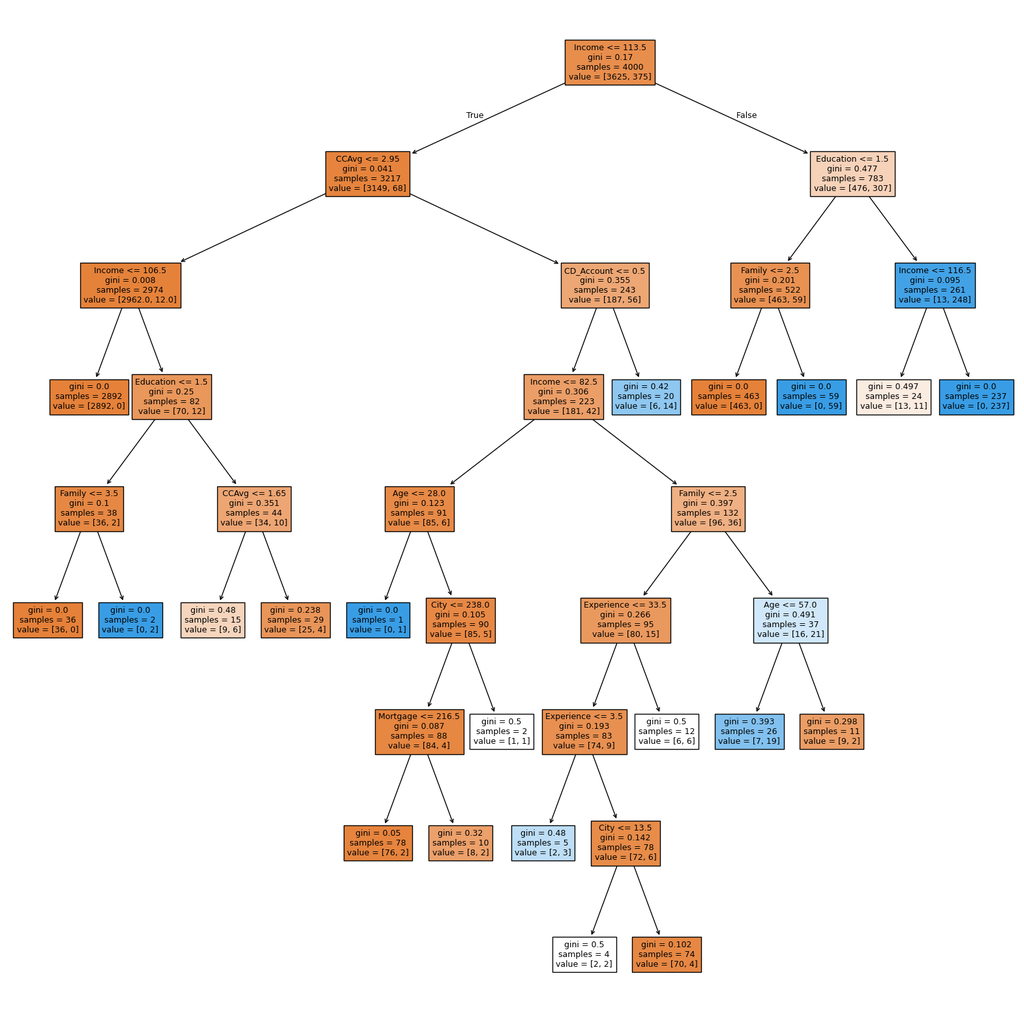

```python
# list of feature names in X_train
feature_names = list(X_train.columns)

# set the figure size for the plot
plt.figure(figsize=(20, 20))

# plotting the decision tree
out = tree.plot_tree(
    dtree2,                         # decision tree classifier model
    feature_names=feature_names,    # list of feature names (columns) in the dataset
    filled=True,                    # fill the nodes with colors based on class
    fontsize=9,                     # font size for the node text
    node_ids=False,                 # do not show the ID of each node
    class_names=None,               # whether or not to display class names
)

# add arrows to the decision tree splits if they are missing
for o in out:
    arrow = o.arrow_patch
    if arrow is not None:
        arrow.set_edgecolor("black")    # set arrow color to black
        arrow.set_linewidth(1)          # set arrow linewidth to 1

# displaying the plot
plt.show()
```

### This is a far less complex tree than the previous one. We can observe the decision rules much more clearly in the plot.

```python
# printing a text report showing the rules of a decision tree
print(
    tree.export_text(
        dtree2,    # specify the model
        feature_names=feature_names,    # specify the feature names
        show_weights=True    # specify whether or not to show the weights associated with the model
    )
)
```

```
|--- Income <= 113.50
|   |--- CCAvg <= 2.95
|   |   |--- Income <= 106.50
|   |   |   |--- weights: [2892.00, 0.00] class: 0
|   |   |--- Income >  106.50
|   |   |   |--- Education <= 1.50
|   |   |   |   |--- Family <= 3.50
|   |   |   |   |   |--- weights: [36.00, 0.00] class: 0
|   |   |   |   |--- Family >  3.50
|   |   |   |   |   |--- weights: [0.00, 2.00] class: 1
|   |   |   |--- Education >  1.50
|   |   |   |   |--- CCAvg <= 1.65
|   |   |   |   |   |--- weights: [9.00, 6.00] class: 0
|   |   |   |   |--- CCAvg >  1.65
|   |   |   |   |   |--- weights: [25.00, 4.00] class: 0
|   |--- CCAvg >  2.95
|   |   |--- CD_Account <= 0.50
|   |   |   |--- Income <= 82.50
|   |   |   |   |--- Age <= 28.00
|   |   |   |   |   |--- weights: [0.00, 1.00] class: 1
|   |   |   |   |--- Age >  28.00
|   |   |   |   |   |--- City <= 238.00
|   |   |   |   |   |   |--- Mortgage <= 216.50
|   |   |   |   |   |   |   |--- weights: [76.00, 2.00] class: 0
|   |   |   |   |   |   |--- Mortgage >  216.50
|   |   |   |   |   |   |   |--- weights: [8.00, 2.00] class: 0
|   |   |   |   |   |--- City >  238.00
|   |   |   |   |   |   |--- weights: [1.00, 1.00] class: 0
|   |   |   |--- Income >  82.50
|   |   |   |   |--- Family <= 2.50
|   |   |   |   |   |--- Experience <= 33.50
|   |   |   |   |   |   |--- Experience <= 3.50
|   |   |   |   |   |   |   |--- weights: [2.00, 3.00] class: 1
|   |   |   |   |   |   |--- Experience >  3.50
|   |   |   |   |   |   |   |--- City <= 13.50
|   |   |   |   |   |   |   |   |--- weights: [2.00, 2.00] class: 0
|   |   |   |   |   |   |   |--- City >  13.50
|   |   |   |   |   |   |   |   |--- weights: [70.00, 4.00] class: 0
|   |   |   |   |   |--- Experience >  33.50
|   |   |   |   |   |   |--- weights: [6.00, 6.00] class: 0
|   |   |   |   |--- Family >  2.50
|   |   |   |   |   |--- Age <= 57.00
|   |   |   |   |   |   |--- weights: [7.00, 19.00] class: 1
|   |   |   |   |   |--- Age >  57.00
|   |   |   |   |   |   |--- weights: [9.00, 2.00] class: 0
|   |   |--- CD_Account >  0.50
|   |   |   |--- weights: [6.00, 14.00] class: 1
|--- Income >  113.50
|   |--- Education <= 1.50
|   |   |--- Family <= 2.50
|   |   |   |--- weights: [463.00, 0.00] class: 0
|   |   |--- Family >  2.50
|   |   |   |--- weights: [0.00, 59.00] class: 1
|   |--- Education >  1.50
|   |   |--- Income <= 116.50
|   |   |   |--- weights: [13.00, 11.00] class: 0
|   |   |--- Income >  116.50
|   |   |   |--- weights: [0.00, 237.00] class: 1
```

# Decision Tree (Post-pruning)

```python
# Create an instance of the decision tree model
clf = DecisionTreeClassifier(random_state=42)

# Compute the cost complexity pruning path for the model using the training data
path_1 = clf.cost_complexity_pruning_path(X_train, y_train)

# Extract the array of effective alphas from the pruning path
ccp_alphas = abs(path_1.ccp_alphas)

# Extract the array of total impurities at each alpha along the pruning path
impurities = path_1.impurities
```

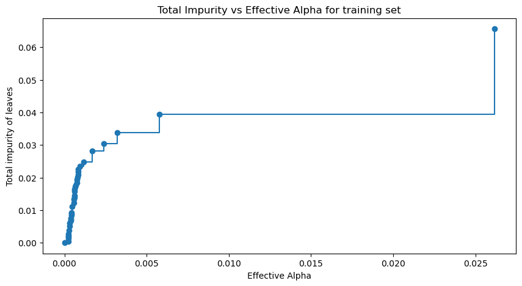

```python
# Create a figure
fig, ax = plt.subplots(figsize=(10, 5))

# Plot the total impurities versus effective alphas, excluding the last value,
# using markers at each data point and connecting them with steps
ax.plot(ccp_alphas[:-1], impurities[:-1], marker="o", drawstyle="steps-post")

# Set the x-axis label
ax.set_xlabel("Effective Alpha")

# Set the y-axis label
ax.set_ylabel("Total impurity of leaves")

# Set the title of the plot
ax.set_title("Total Impurity vs Effective Alpha for training set");
```

```python
# Initialize an empty list to store the decision tree classifiers
clfs = []

# Iterate over each ccp_alpha value extracted from cost complexity pruning path
for ccp_alpha in ccp_alphas:
    # Create an instance of the DecisionTreeClassifier
    clf = DecisionTreeClassifier(ccp_alpha=ccp_alpha, random_state=42)

    # Fit the classifier to the training data
    clf.fit(X_train, y_train)

    # Append the trained classifier to the list
    clfs.append(clf)

# Print the number of nodes in the last tree along with its ccp_alpha value
print(
    "Number of nodes in the last tree is {} with ccp_alpha {}".format(
        clfs[-1].tree_.node_count, ccp_alphas[-1]
    )
)
```

```
Number of nodes in the last tree is 1 with ccp_alpha 0.05214930148943829
```

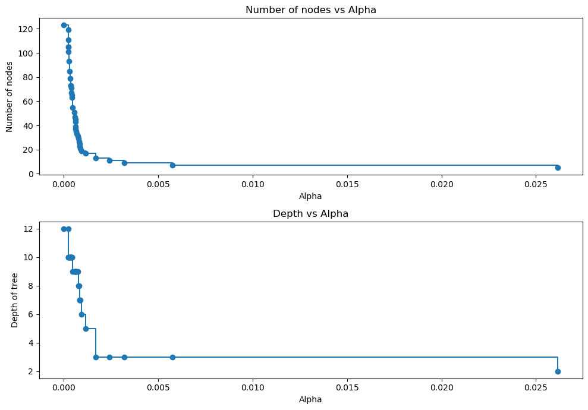

```python
# Remove the last classifier and corresponding ccp_alpha value from the lists
clfs = clfs[:-1]
ccp_alphas = ccp_alphas[:-1]

# Extract the number of nodes in each tree classifier
node_counts = [clf.tree_.node_count for clf in clfs]

# Extract the maximum depth of each tree classifier
depth = [clf.tree_.max_depth for clf in clfs]

# Create a figure and a set of subplots
fig, ax = plt.subplots(2, 1, figsize=(10, 7))

# Plot the number of nodes versus ccp_alphas on the first subplot
ax[0].plot(ccp_alphas, node_counts, marker="o", drawstyle="steps-post")
ax[0].set_xlabel("Alpha")
ax[0].set_ylabel("Number of nodes")
ax[0].set_title("Number of nodes vs Alpha")

# Plot the depth of tree versus ccp_alphas on the second subplot
ax[1].plot(ccp_alphas, depth, marker="o", drawstyle="steps-post")
ax[1].set_xlabel("Alpha")
ax[1].set_ylabel("Depth of tree")
ax[1].set_title("Depth vs Alpha")

# Adjust the layout of the subplots to avoid overlap
fig.tight_layout()
```

```python
train_f1_scores = []  # Initialize an empty list to store F1 scores for training set for each decision tree classifier

# Iterate through each decision tree classifier in 'clfs'
for clf in clfs:
    # Predict labels for the training set using the current decision tree classifier
    pred_train = clf.predict(X_train)

    # Calculate the F1 score for the training set predictions compared to true labels
    f1_train = f1_score(y_train, pred_train)

    # Append the calculated F1 score to the train_f1_scores list
    train_f1_scores.append(f1_train)
```

```python
test_f1_scores = []  # Initialize an empty list to store F1 scores for test set for each decision tree classifier

# Iterate through each decision tree classifier in 'clfs'
for clf in clfs:
    # Predict labels for the test set using the current decision tree classifier
    pred_test = clf.predict(X_test)

    # Calculate the F1 score for the test set predictions compared to true labels
    f1_test = f1_score(y_test, pred_test)

    # Append the calculated F1 score to the test_f1_scores list
    test_f1_scores.append(f1_test)
```

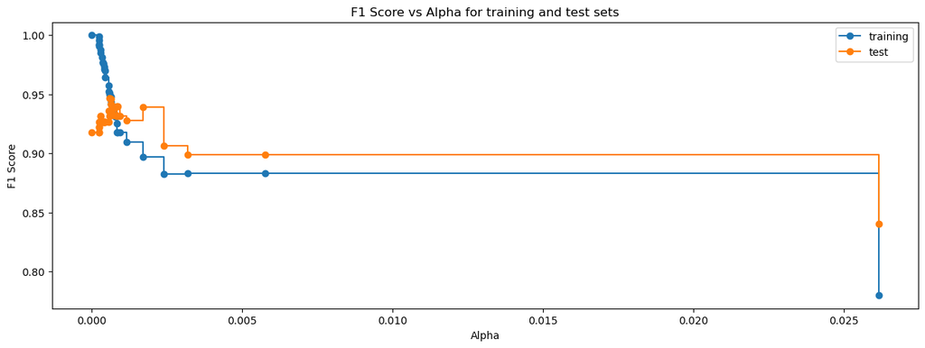

```python
# Create a figure
fig, ax = plt.subplots(figsize=(15, 5))
ax.set_xlabel("Alpha")  # Set the label for the x-axis
ax.set_ylabel("F1 Score")  # Set the label for the y-axis
ax.set_title("F1 Score vs Alpha for training and test sets")  # Set the title of the plot

# Plot the training F1 scores against alpha, using circles as markers and steps-post style
ax.plot(ccp_alphas, train_f1_scores, marker="o", label="training", drawstyle="steps-post")

# Plot the testing F1 scores against alpha, using circles as markers and steps-post style
ax.plot(ccp_alphas, test_f1_scores, marker="o", label="test", drawstyle="steps-post")

ax.legend();  # Add a legend to the plot
```

```python
# creating the model where we get highest test F1 Score
index_best_model = np.argmax(test_f1_scores)

# selcting the decision tree model corresponding to the highest test score
dtree3 = clfs[index_best_model]
print(dtree3)
```

```
DecisionTreeClassifier(ccp_alpha=np.float64(0.0006000000000000003),
                       random_state=42)
```

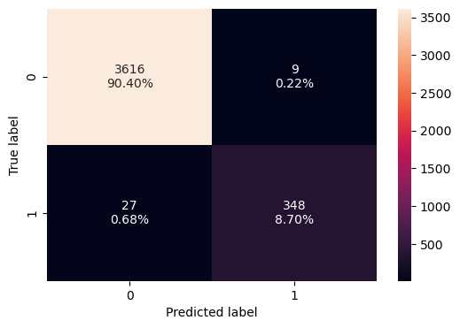

```python
plot_confusion_matrix(dtree3, X_train, y_train)
```

```python
dtree3_train_perf = model_performance_classification(
    dtree3, X_train, y_train
)
dtree3_train_perf
```

|  | Accuracy | Recall | Precision | F1 |
| --- | --- | --- | --- | --- |
| 0 | 0.991 | 0.928 | 0.97479 | 0.95082 |

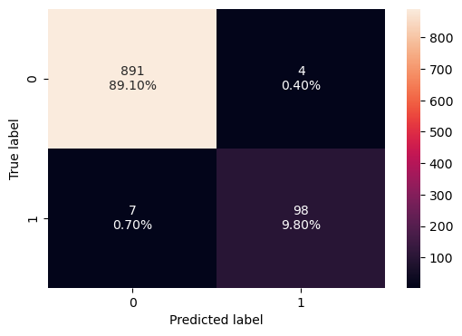

```python
plot_confusion_matrix(dtree3, X_test, y_test)
```

```python
dtree3_test_perf = model_performance_classification(
    dtree3, X_test, y_test
)
dtree3_test_perf
```

|  | Accuracy | Recall | Precision | F1 |
| --- | --- | --- | --- | --- |
| 0 | 0.989 | 0.933333 | 0.960784 | 0.94686 |

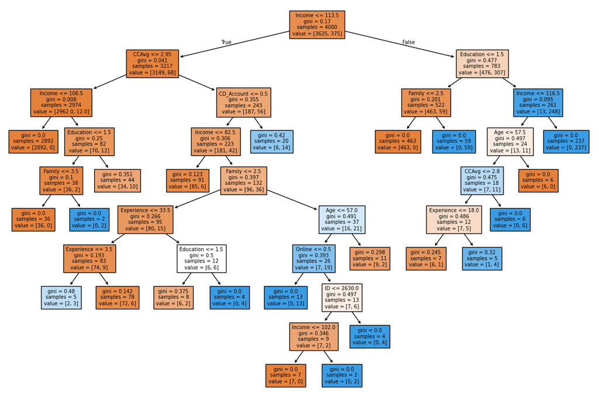

```python
# list of feature names in X_train
feature_names = list(X_train.columns)

# set the figure size for the plot
plt.figure(figsize=(15, 10))

# plotting the decision tree
out = tree.plot_tree(
    dtree3,                         # decision tree classifier model
    feature_names=feature_names,    # list of feature names (columns) in the dataset
    filled=True,                    # fill the nodes with colors based on class
    fontsize=7,                     # font size for the node text
    node_ids=False,                 # do not show the ID of each node
    class_names=None,               # whether or not to display class names
)

# add arrows to the decision tree splits if they are missing
for o in out:
    arrow = o.arrow_patch
    if arrow is not None:
        arrow.set_edgecolor("black")    # set arrow color to black
        arrow.set_linewidth(1)          # set arrow linewidth to 1
```

```python
# printing a text report showing the rules of a decision tree
print(
    tree.export_text(
        dtree3,    # specify the model
        feature_names=feature_names,    # specify the feature names
        show_weights=True    # specify whether or not to show the weights associated with the model
    )
)
```

```
|--- Income <= 113.50
|   |--- CCAvg <= 2.95
|   |   |--- Income <= 106.50
|   |   |   |--- weights: [2892.00, 0.00] class: 0
|   |   |--- Income >  106.50
|   |   |   |--- Education <= 1.50
|   |   |   |   |--- Family <= 3.50
|   |   |   |   |   |--- weights: [36.00, 0.00] class: 0
|   |   |   |   |--- Family >  3.50
|   |   |   |   |   |--- weights: [0.00, 2.00] class: 1
|   |   |   |--- Education >  1.50
|   |   |   |   |--- weights: [34.00, 10.00] class: 0
|   |--- CCAvg >  2.95
|   |   |--- CD_Account <= 0.50
|   |   |   |--- Income <= 82.50
|   |   |   |   |--- weights: [85.00, 6.00] class: 0
|   |   |   |--- Income >  82.50
|   |   |   |   |--- Family <= 2.50
|   |   |   |   |   |--- Experience <= 33.50
|   |   |   |   |   |   |--- Experience <= 3.50
|   |   |   |   |   |   |   |--- weights: [2.00, 3.00] class: 1
|   |   |   |   |   |   |--- Experience >  3.50
|   |   |   |   |   |   |   |--- weights: [72.00, 6.00] class: 0
|   |   |   |   |   |--- Experience >  33.50
|   |   |   |   |   |   |--- Education <= 1.50
|   |   |   |   |   |   |   |--- weights: [6.00, 2.00] class: 0
|   |   |   |   |   |   |--- Education >  1.50
|   |   |   |   |   |   |   |--- weights: [0.00, 4.00] class: 1
|   |   |   |   |--- Family >  2.50
|   |   |   |   |   |--- Age <= 57.00
|   |   |   |   |   |   |--- Online <= 0.50
|   |   |   |   |   |   |   |--- weights: [0.00, 13.00] class: 1
|   |   |   |   |   |   |--- Online >  0.50
|   |   |   |   |   |   |   |--- ID <= 2630.00
|   |   |   |   |   |   |   |   |--- Income <= 102.00
|   |   |   |   |   |   |   |   |   |--- weights: [7.00, 0.00] class: 0
|   |   |   |   |   |   |   |   |--- Income >  102.00
|   |   |   |   |   |   |   |   |   |--- weights: [0.00, 2.00] class: 1
|   |   |   |   |   |   |   |--- ID >  2630.00
|   |   |   |   |   |   |   |   |--- weights: [0.00, 4.00] class: 1
```

[output cut: 9 more lines]

```
|   |   |   |--- weights: [0.00, 59.00] class: 1
|   |--- Education >  1.50
|   |   |--- Income <= 116.50
|   |   |   |--- Age <= 57.50
|   |   |   |   |--- CCAvg <= 2.80
|   |   |   |   |   |--- Experience <= 18.00
|   |   |   |   |   |   |--- weights: [6.00, 1.00] class: 0
|   |   |   |   |   |--- Experience >  18.00
|   |   |   |   |   |   |--- weights: [1.00, 4.00] class: 1
|   |   |   |   |--- CCAvg >  2.80
|   |   |   |   |   |--- weights: [0.00, 6.00] class: 1
|   |   |   |--- Age >  57.50
|   |   |   |   |--- weights: [6.00, 0.00] class: 0
|   |   |--- Income >  116.50
|   |   |   |--- weights: [0.00, 237.00] class: 1
```

Model Performance Comparison and Final Model Selection

```python
# training performance comparison

models_train_comp_df = pd.concat(
    [
        dtree1_train_perf.T,
        dtree2_train_perf.T,
        dtree3_train_perf.T,
    ],
    axis=1,
)
models_train_comp_df.columns = [
    "Decision Tree (sklearn default)",
    "Decision Tree (Pre-Pruning)",
    "Decision Tree (Post-Pruning)",
]
print("Train Data performance comparison:")

models_train_comp_df= models_train_comp_df.round(2)
models_train_comp_df
```

```
Train Data performance comparison:
```

|  | Decision Tree (sklearn default) | Decision Tree (Pre-Pruning) | Decision Tree (Post-Pruning) |
| --- | --- | --- | --- |
| Accuracy | 1.0 | 0.99 | 0.99 |
| Recall | 1.0 | 0.89 | 0.93 |
| Precision | 1.0 | 0.96 | 0.97 |
| F1 | 1.0 | 0.92 | 0.95 |

```python
# testing performance comparison

models_test_comp_df = pd.concat(
    [
        dtree1_test_perf.T,
        dtree2_test_perf.T,
        dtree3_test_perf.T,
    ],
    axis=1,
)
models_test_comp_df.columns = [
    "Decision Tree (sklearn default)",
    "Decision Tree (Pre-Pruning)",
    "Decision Tree (Post-Pruning)",
]

models_test_comp_df = models_test_comp_df.round(2)
print("Test set performance comparison:")
models_test_comp_df
```

```
Test set performance comparison:
```

|  | Decision Tree (sklearn default) | Decision Tree (Pre-Pruning) | Decision Tree (Post-Pruning) |
| --- | --- | --- | --- |
| Accuracy | 0.98 | 0.99 | 0.99 |
| Recall | 0.90 | 0.91 | 0.93 |
| Precision | 0.93 | 0.95 | 0.96 |
| F1 | 0.92 | 0.93 | 0.95 |